# Who Controls the Networks Global Business Depends On?

Stephen Weymouth

Dean’s Professor

2026-11-18

# On September 15, 2005, the U.S. Treasury blacklisted one small bank in Macau. Depositors started a run on the bank, and Macau’s government took control of it.

## Your IB Voice

Power beyond borders

After the U.S. Treasury blacklisted one small bank in Macau, banks around the world stopped doing business with North Korea. Using Farrell and Newman, explain how the United States gets this power over firms in other countries.

**10 minutes** · Individual · Notes permitted

# “Once, when multinational corporations thought about political risk, they feared kleptocratic dictators. Now they worried that America might press them into service or China might retaliate.” Farrell and Newman

# Why do the world’s networks run through the United States?

# “Just as all roads once led to Rome, the world’s fiber-optic networks, financial systems, and semiconductor supply chains converge on the United States, allowing it to project its might.” Farrell and Newman

## Four networks converged on the United States

[figure not shown]

Farrell and Newman, *Underground Empire*, 2023, Introduction.

*Path dependence*: early choices constrain later ones. The networks took shape when the United States was at the center of everything, and later builders kept building on them.

## Emails within Brazil could travel through Miami

[figure not shown]

Farrell and Newman, *Underground Empire*, 2023: the authors’ example.

Internet traffic takes the cheapest and fastest path, which is not always the shortest.

Fiber-optic cables through the United States could beat Brazil’s own copper lines.

A *hub* is a point where many routes converge, so much of the traffic passes through it, and whoever governs the hub can reach that traffic.

## The dollar is in 89 of every 100 currency trades

[figure not shown]

Bank for International Settlements, [Triennial Central Bank Survey](https://www.bis.org/statistics/rpfx25_fx.htm), 2025: turnover in April 2025.

A trade of Mexican pesos for Korean won usually runs through the dollar: pesos into dollars, then dollars into won.

Treasury officials knew that “major businesses simply couldn’t function without access to U.S. dollars.”

# What can the United States surveil?

## In 2000 the NSA was losing its ability to listen

[figure not shown]

National Security Agency, [Michael V. Hayden as NSA director](https://commons.wikimedia.org/wiki/File:Michael_V._Hayden_as_NSA_director.jpg), about 1999 to 2005 · Wikimedia Commons, public domain

The National Security Agency (NSA) listens to foreign communications, but fiber-optic cables do not leak signals the way copper wires and satellite links did.

Congress had cut the agency’s budget by 30 percent, and its internal network once crashed for days.

Farrell and Newman: “The NSA’s power to surveil rested not just on the law but on the map.”

# Months after an NSA visit in 2002, an AT&T technician in San Francisco heard that a secret room was being built on the sixth floor, behind a door marked 641A.

## AT&T copied Internet traffic for the NSA

[figure not shown]

Farrell and Newman, *Underground Empire*, 2023, drawing on Mark Klein’s account.

The NSA tapped eight AT&T sites, including this one, and seven on Verizon’s network.

In 2011 the NSA budgeted $394 million for its corporate partners.

Because U.S. firms ran the hubs, the government could pay or order them to help.

# A U.S. official called SWIFT’s records a “Rosetta Stone”: they let Treasury read who sent money where, and when.

## SWIFT is how banks tell each other to pay

[figure not shown]

The wub, [Siemens T100-R teleprinter, 1962](https://commons.wikimedia.org/wiki/File:Siemens_T100-R_teleprinter,_1962_-_National_Army_Museum.jpg) · Wikimedia Commons, CC BY-SA 4.0

When a firm pays a supplier abroad, its bank sends the supplier’s bank a SWIFT message: pay this amount into this account. More than 11,500 institutions use it.

Banks set up SWIFT, the Society for Worldwide Interbank Financial Telecommunication, in Belgium in 1973 to replace telex machines like this one.

SWIFT carries the messages, not the money, but its records show who paid whom, and when.

## Europe kept the program

When the secret SWIFT program became public in 2006, European governments did not end it. They negotiated a deal to keep it, with new safeguards. Why?

## Seeing: the panopticon effect

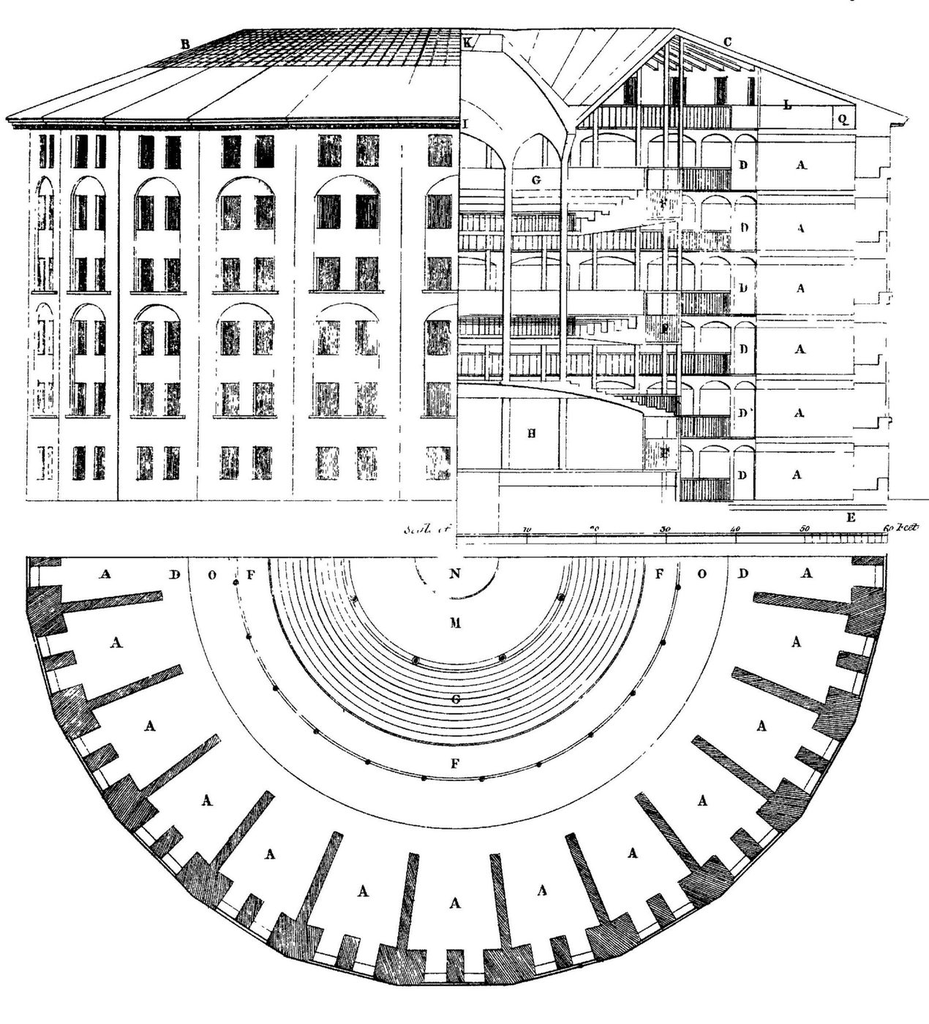

Willey Reveley for Jeremy Bentham, [*Panopticon*](https://commons.wikimedia.org/wiki/File:Panopticon.jpg), 1791 · Wikimedia Commons, public domain

A state that controls a hub can watch what passes through it.

Firms that use the hub cannot tell when they are being watched.

Farrell and Newman name this the *panopticon effect*, after Jeremy Bentham’s design for a prison in which one guard could see every cell.

# What can the United States cut off?

## Most dollar payments abroad settle in New York

[figure not shown]

An illustrative payment, simplified; Farrell and Newman, *Underground Empire*, 2023, Chapter 2.

In *dollar clearing*, each foreign bank keeps a dollar account at a U.S. bank. In New York, the German bank’s U.S. bank pays the Saudi bank’s U.S. bank, often through CHIPS, the Clearing House Interbank Payments System.

When Treasury blacklists a foreign bank, it can lose its dollar account, and other banks drop it to protect their own.

## The $25 million

North Korea spent nearly two years trying to recover $25 million frozen at the bank in Macau. Why did so little money matter so much to it?

## Banks paid billions for hiding sanctioned clients

[figure not shown]

Settlements with U.S. authorities, as reported by Bloomberg Law, American Banker, Fortune, AP, and Ropes & Gray.

Most had moved dollar payments through New York for clients in Iran, Sudan, or Cuba and removed the clients’ names so U.S. screens would miss them.

Fear of losing dollars made foreign banks enforce U.S. rules on their own customers.

## In 2012 SWIFT cut off Iran’s banks

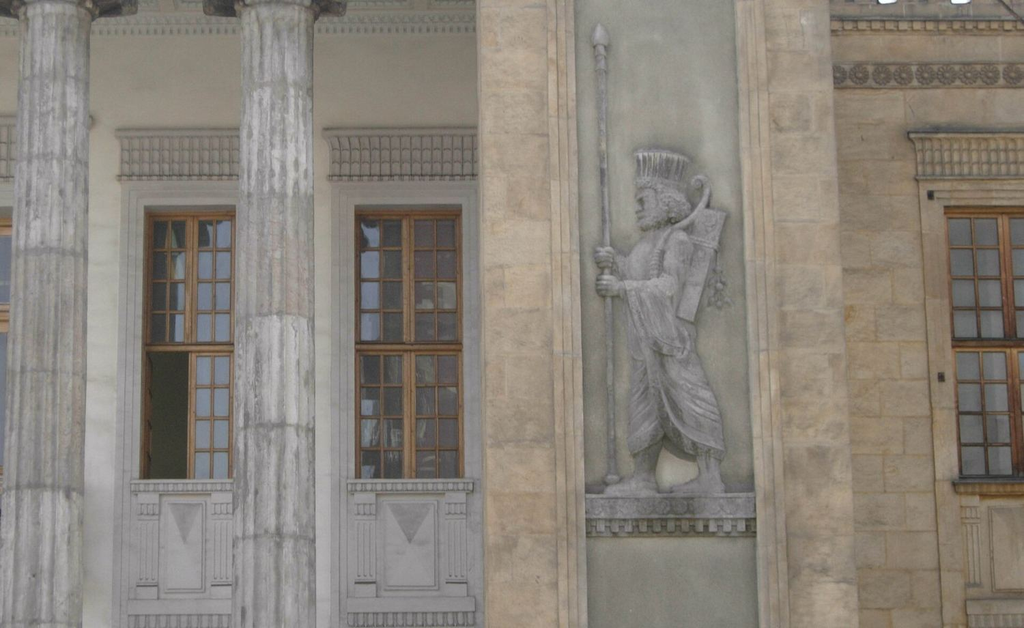

xiquinhosilva, [Bank Melli Iran in Tehran](https://commons.wikimedia.org/wiki/File:Bank_Melli_Iran_in_Tehran.jpg), 2008 · Wikimedia Commons, CC BY 2.0

[figure not shown]

Iran lost both the dollars and the messages that banks use to pay one another.

## Cutting off: the chokepoint effect

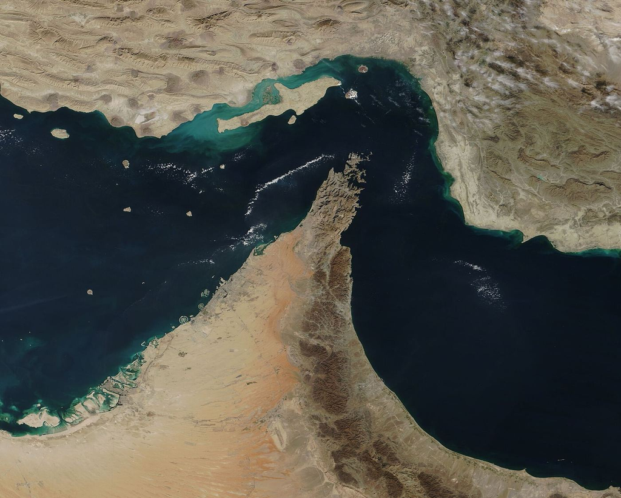

NASA, Strait of Hormuz and Musandam Peninsula, December 2018 · Wikimedia Commons, public domain

A state that controls a hub can deny others its use.

Firms enforce the cutoff themselves, because each fears being cut off next.

Watching and cutting off are the two sides of what Farrell and Newman call *weaponized interdependence*: turning other countries’ dependence on a network into power over them.

# “The day that cooperation becomes dependence, you have become somebody’s vassal and you disappear.” Emmanuel Macron, president of France

## Europe tried to keep Iran trade payments at home

[figure not shown]

German Federal Foreign Office and U.K. government, 2019 to 2023; simplified.

After 2018, most European banks would not touch payments with Iran for fear of U.S. penalties.

France, Germany, and Britain created INSTEX (Instrument in Support of Trade Exchanges), and Iran created STFI (Special Trade and Finance Instrument).

It completed one deal in four years, after large European firms had left Iran rather than risk their U.S. business.

## China’s system settles a twentieth of New York’s

[figure not shown]

The Clearing House, [CHIPS Annual Statistics](https://www.theclearinghouse.org/payment-systems/CHIPS/CHIPS-Annual-Statistics); People’s Bank of China, 2025 payment system report.

CHIPS, the Clearing House Interbank Payments System, is the private system in New York where banks settle large dollar payments.

In 2015 China launched CIPS, the Cross-Border Interbank Payment System, so firms can settle cross-border payments in yuan without dollars or New York. In 2024, 27.2 percent of China’s cross-border goods trade was settled in yuan, and 28.1 percent in the first half of 2025.

A new network grows slowly, because firms use the one their partners already use.

# After the Snowden leaks and the U.S. campaigns against the Chinese telecom firms ZTE and Huawei, China built export controls and investment screening of its own.

# In April 2025 the United States raised tariffs on China. China held no chokepoint in chips, so it answered with rare earths.

## China refines most of the world’s rare earths

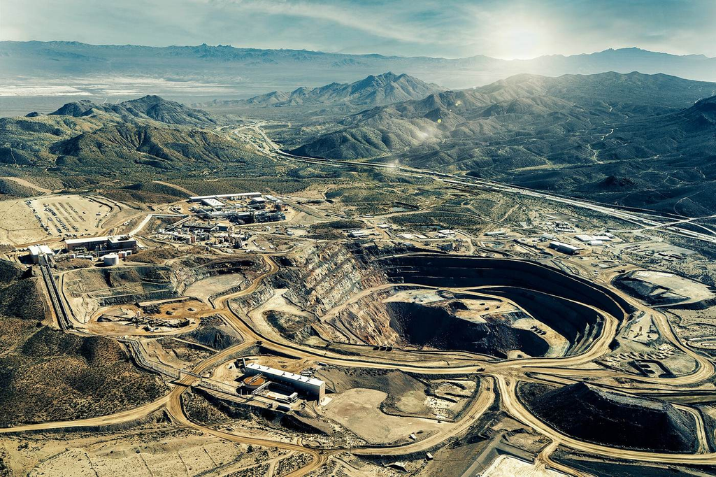

Tmy350, [Mountain Pass Rare Earth Mine & Processing Facility](https://commons.wikimedia.org/wiki/File:Mountain_Pass_Rare_Earth_Mine_%26_Processing_Facility.jpg), 2022 · Wikimedia Commons, CC BY-SA 4.0

Rare earths are 17 metals; magnets made from some of them run electric-car motors, wind turbines, phones, and missiles.

[figure not shown]

International Energy Agency, [*Rare Earth Elements*](https://www.iea.org/reports/rare-earth-elements/executive-summary), 2026: shares of world output in 2024.

Rare earths are China’s chokepoint, as dollar clearing is America’s.

## Export restrictions have risen sevenfold

[figure not shown]

Farrell, Newman, and Tan, “The Chokepoint Trap,” *Foreign Affairs*, 2026, citing Global Trade Alert.

A bill introduced in Congress names smart ovens and clothes dryers as possible security threats.

As chokepoints multiply, even ordinary trade starts to look like a security risk.

## Escalating: the chokepoint trap

[figure not shown]

Farrell, Newman, and Tan, “The Chokepoint Trap,” *Foreign Affairs*, 2026; U.S. Commerce Department; China’s Ministry of Commerce.

Each defense looks like a threat to the others.

Each reply comes through a different network.

Farrell, Newman, and Tan call this the *chokepoint trap*: the security dilemma in the world economy.

## Trump, Xi, and Putin meet in Shenzhen

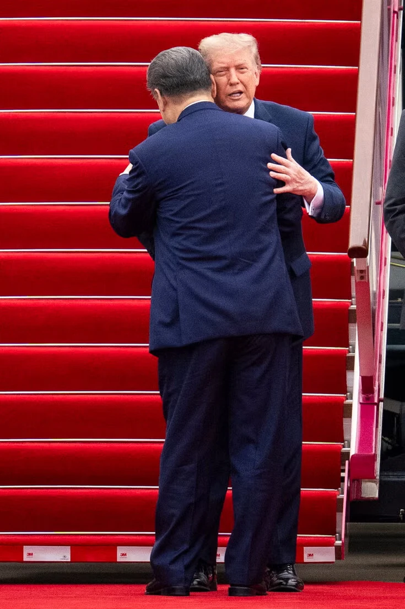

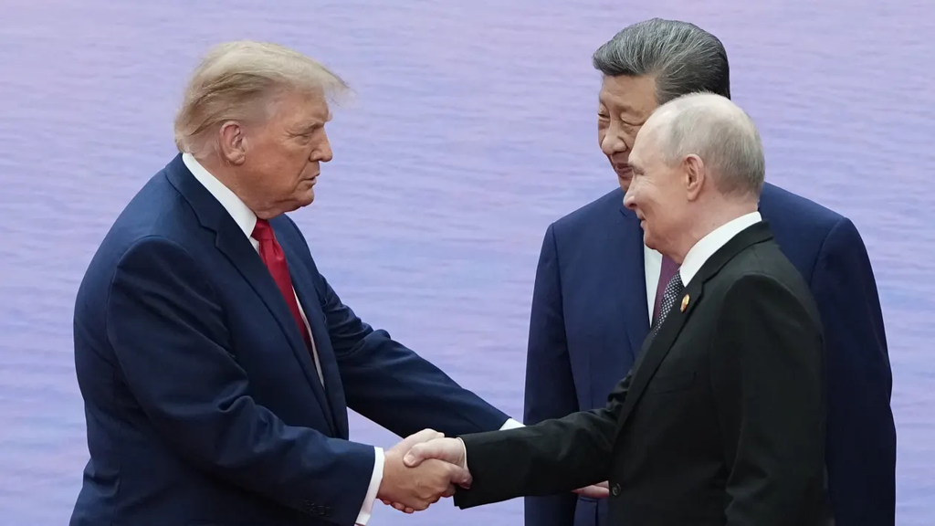

Left: Xi greets Trump on his arrival in Shenzhen. Right: Trump and Putin shake hands as Xi looks on, November 18, 2026. Photographs supplied by the instructor.

On November 19, at the Asia-Pacific Economic Cooperation (APEC) summit, the three leaders hold their first three-way meeting, expected to cover the Iran war and nuclear arms. Trump and Xi also take up tariffs, chips, and rare earths.

Each leader arrives holding a chokepoint: the dollar and chips, rare earths, and oil and gas.

## A carmaker’s wish

You run a European carmaker that buys chips and magnets from China and sells cars in the United States. What one agreement would you want from tomorrow’s meeting?

# Advise a firm caught between the hubs

## Advise a firm caught in the networks

1. Total, 2018: U.S. sanctions return on its Iran gas project
2. Huawei, 2013: HSBC asks about an affiliate selling to Iran
3. Petrobras, 2013: leaked NSA slides list it as a target
4. Nexperia, owned by China’s Wingtech, 2025: new U.S. export rules reach it

Name the network your firm depends on and who controls it.

Decide whether that government can watch the firm, cut it off, or both.

Estimate what switching to a substitute would cost.

Choose one response, or a mix, and defend it with one passage from the readings.

15 minutes · Groups of four · Reading permitted

Possible responses

Leave the market · Seek a waiver · Switch banks, suppliers, or routes · Move production · Protect sensitive data · Sell down a foreign owner’s stake

## Report out

Which response did your firm choose, and what would it cost?

## Political risk now runs through networks

### If a state can watch the network

Assume that payment and message records can be read by the government that controls the hub.

Choose where data is stored and which networks carry it, as Brazil and the EU did by backing a direct cable.

### If a state can cut the network off

Access to dollars, chips, or rare earths can be withdrawn by a government, not only by a market.

Banks and suppliers will drop a customer to protect their own access, so a firm’s partners become enforcers.

Farrell and Newman: firms now worry “that America might press them into service or China might retaliate.”

## Closing discussion

Farrell and Newman write that firms are now “stranded in the no-man’s-land between warring empires.” Should a multinational try to stay neutral, or pick a side?

On Monday, November 23, Anu Bradford compares how the United States, China, and the European Union govern digital firms.

## Takeaways

Who controls the networks global business depends on?

The networks firms rely on converge on a few hubs, most of them in the United States.

Whoever governs a hub can watch the firms that use it.

It can also cut them off, and banks and suppliers enforce the cutoff themselves.

Other powers now build chokepoints of their own, so a firm faces political risk from several governments at once.